# Practical Machine Learning

## R Markdown

```r
setwd("C:\\Users\\Nastya\\Documents\\Coursera\\Practical Machine Learning")

library(caret)
```

```r
library(rpart.plot)
library(pgmm)
library(gbm)
library(rpart)
library(rattle)
# create dataframes for the training and testing data

training<-read.csv(file="pml-training.csv", header=TRUE, sep=",")
dim(training)
```

```
## [1] 19622   160
```

```r
testing<-read.csv(file="pml-testing.csv",header=TRUE,sep=",")
dim(testing)
```

```
## [1]  20 160
```

```r
str(training)
```

[output not shown]

[output cut: 86 more lines]

```r
summary(training)
```

[output not shown]

[output cut: 313 more lines]

[output not shown]

Before using the machine learning techniques, it is important to consider only informative variables in the model. The total number of variables except the response variable that are available in the training dataset is equal to 159. However, there exist variables that have little predictive power due to many missing observations. These variables should be removed from the analysis. Additionally, we remove the variables that correspond to the infromation about the participants of the experiment and the timestamps as well as varables that have yero variability.

```r
# This part of the code sets the index for the variables that have equall or more than 90% of missing values (NA or blank) in the training set

indexMissing <- which(colSums(is.na(training)|training=="")>=0.9*dim(training)[1])
trainClean <- training[,-indexMissing]
# Now we remove first 7 variable since they are not informative for the prediction of the variable classe
trainClean <- trainClean[,-c(1:7)]
# Check whether there are variables with almost zero variance and remove them
nzv<-nearZeroVar(trainClean,saveMetrics=TRUE)
trainClean <- trainClean[,nzv$nzv==FALSE]
dim(trainClean)
```

```
## [1] 19622    53
```

```r
# We do the same for the testing set provided for the evaluation of the models

validationClean <- testing[,-indexMissing]
validationClean <- validationClean[,-c(1:7)]
dim(validationClean)
```

```
## [1] 20 53
```

The cleaned traning set contains 53 variables. On the next step we create a random partition of the training set, so we have an independent validation set.

```r
# Here we create a partition of the traning data set
set.seed(333333)
trainIndex <- createDataPartition(trainClean$classe, p=0.7, list=FALSE)
trainFinal <- trainClean[trainIndex,]
validationFinal <- trainClean[-trainIndex,]
# Now we partition the rest of the data in the training and testing set
inTrain<-createDataPartition(trainFinal$classe, p=0.7, list=FALSE)
trainingFinal<-trainFinal[inTrain,]
testingFinal<-trainFinal[-inTrain,]

dim(trainingFinal)
```

```
## [1] 9619   53
```

```r
dim(testingFinal)
```

```
## [1] 4118   53
```

```r
dim(validationFinal)
```

```
## [1] 5885   53
```

After cleaning the data, in order to chose an appropriate variables for the model and prediction function we will use K-fold cross validation technique with number of folds equal to 10 (what is a common choise among practitioners) in order to avoid overfitting. We will compare the performance of several types of the machine learning techniques: classification tree, random forest and gradient boosting method. # Classification tree

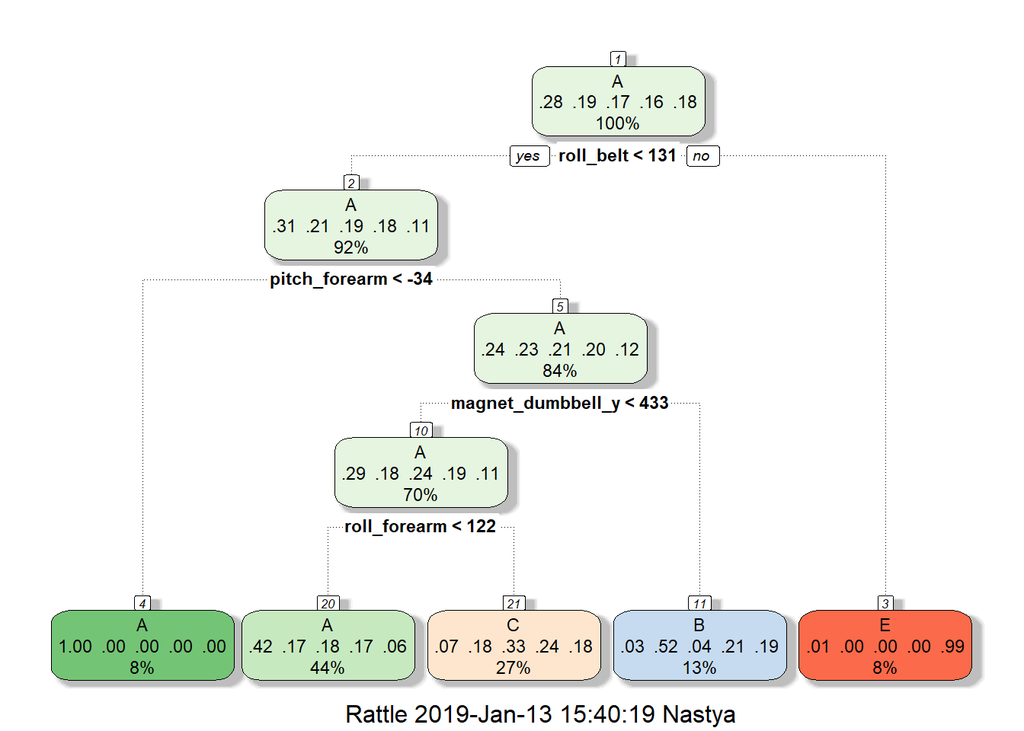

```r
# use trainControl to perform cross-validation with 10 folds while building the models in the training set

trCtrl <- trainControl(method="cv", number=10)

# build a classification tree using the training set
mod_ct<-train(classe~., data=trainingFinal, method="rpart", trControl=trCtrl)

# We can plot the classification tree by using the following command
fancyRpartPlot(mod_ct$finalModel)
```

```r
# then we use the final model to predict values on the training set
trainPred_ct<-predict(mod_ct,testingFinal)

# get the testing errors from the confusion matrix
CM_ct<- confusionMatrix(trainPred_ct,testingFinal$classe)
CM_ct$table
```

```
##           Reference
## Prediction    A    B    C    D    E
##          A 1038  318  325  279  111
##          B   23  283   32  131  106
##          C  108  196  361  265  195
##          D    0    0    0    0    0
##          E    2    0    0    0  345
```

```r
# get the overall accuracy of the prediction on the testing set and out-of-sample error
accuracy_ct<-CM_ct$overall[1]
testing_out_of_sample_error_ct <- 1-accuracy_ct
testing_out_of_sample_error_ct
```

```
##  Accuracy
## 0.5077708
```

The error of the classification of the method is pretty high (**0.5077708**).

# Random forest

```r
# train a random forest

mod_rf <- train(classe~., data=trainingFinal, method="rf", trControl=trCtrl, verbose=FALSE)

print(mod_rf)
```

```
## Random Forest
##
## 9619 samples
##   52 predictor
##    5 classes: 'A', 'B', 'C', 'D', 'E'
##
## No pre-processing
## Resampling: Cross-Validated (10 fold)
## Summary of sample sizes: 8656, 8656, 8657, 8657, 8658, 8658, ...
## Resampling results across tuning parameters:
##
##   mtry  Accuracy   Kappa
##    2    0.9879405  0.9847431
##   27    0.9882521  0.9851381
##   52    0.9780618  0.9722412
##
## Accuracy was used to select the optimal model using the largest value.
## The final value used for the model was mtry = 27.
```

```r
# predict values of the testing set

trainPred_rf <- predict(mod_rf,newdata=testingFinal)

CM_rf <- confusionMatrix(trainPred_rf,testingFinal$classe)

# display confusion matrix, model accuracy and overall error rate
CM_rf$table
```

```
##           Reference
## Prediction    A    B    C    D    E
##          A 1164    6    0    0    0
##          B    3  787    9    3    1
##          C    3    1  703   11    2
##          D    0    3    5  659    3
##          E    1    0    1    2  751
```

```r
accuracy_rf<-CM_rf$overall[1]
testing_out_of_sample_error_rf <- 1 - accuracy_rf
testing_out_of_sample_error_rf
```

```
##   Accuracy
## 0.01311316
```

Next candidate method is boosting with trees.

# Boosting

```r
mod_gbm <- train(classe~., data=trainingFinal, method="gbm", trControl=trCtrl, verbose=FALSE)
print(mod_gbm)
```

```
## Stochastic Gradient Boosting
##
## 9619 samples
##   52 predictor
##    5 classes: 'A', 'B', 'C', 'D', 'E'
##
## No pre-processing
## Resampling: Cross-Validated (10 fold)
## Summary of sample sizes: 8657, 8656, 8656, 8657, 8657, 8658, ...
## Resampling results across tuning parameters:
##
##   interaction.depth  n.trees  Accuracy   Kappa
##   1                   50      0.7558926  0.6905770
##   1                  100      0.8204542  0.7727533
##   1                  150      0.8541416  0.8154117
##   2                   50      0.8550739  0.8163609
##   2                  100      0.9084090  0.8840650
##   2                  150      0.9332537  0.9155351
##   3                   50      0.8940598  0.8658361
##   3                  100      0.9403245  0.9244755
##   3                  150      0.9591413  0.9482943
##
## Tuning parameter 'shrinkage' was held constant at a value of 0.1
##
## Tuning parameter 'n.minobsinnode' was held constant at a value of 10
## Accuracy was used to select the optimal model using the largest value.
## The final values used for the model were n.trees = 150,
##  interaction.depth = 3, shrinkage = 0.1 and n.minobsinnode = 10.
```

```r
# predict values of the testing set

trainPred_gbm <- predict(mod_gbm,newdata=testingFinal)

CM_gbm <- confusionMatrix(trainPred_gbm,testingFinal$classe)

# display confusion matrix, model accuracy and overall error rate

CM_gbm$table
```

```
##           Reference
## Prediction    A    B    C    D    E
##          A 1138   20    0    0    3
##          B   22  764   34    0    4
##          C    7   10  668   16    6
##          D    3    0   14  649   13
##          E    1    3    2   10  731
```

```r
accuracy_gbm<-CM_gbm$overall[1]
testing_out_of_sample_error_gbm <- 1 - accuracy_gbm
testing_out_of_sample_error_gbm
```

```
##  Accuracy
## 0.0407965
```

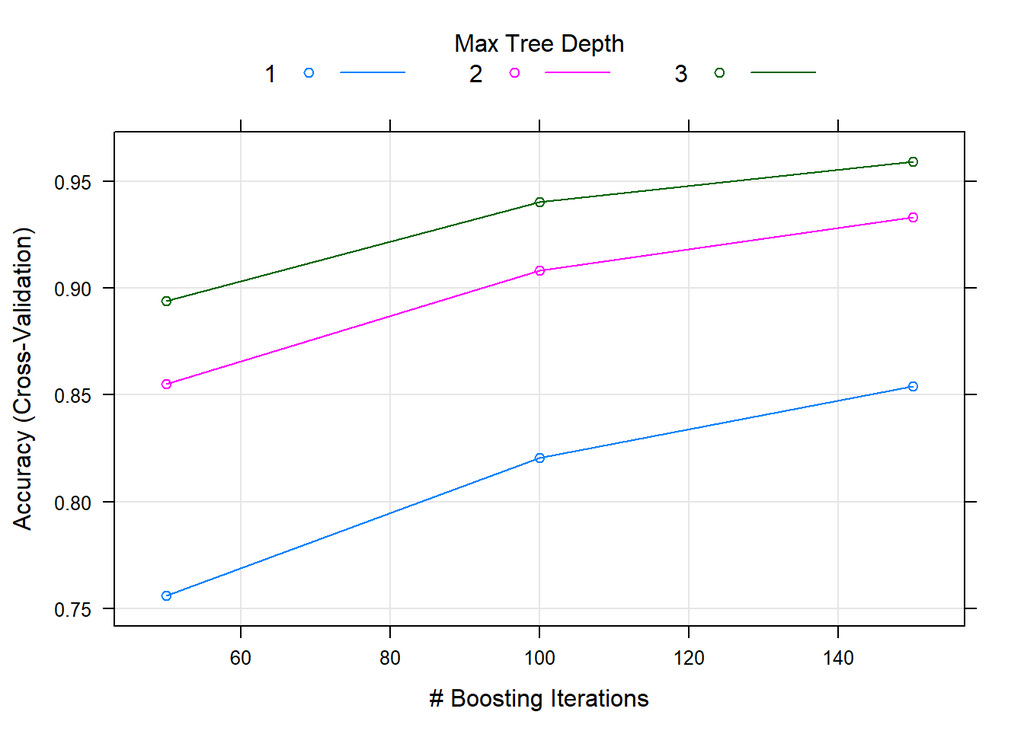

```r
plot(mod_gbm)
```

# Boosting vs Random forest

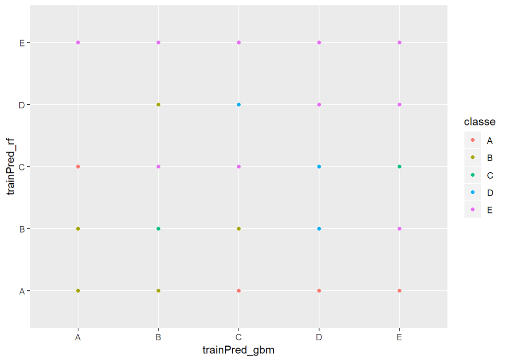

```r
# see the relative performance of rendom forest and glm model in the prediction exercise for the test set
qplot(trainPred_gbm,trainPred_rf,colour=classe,data=testingFinal)
```

```r
# create the data frame with the forecasts on the training set
predDF <- data.frame(trainPred_rf, trainPred_gbm, classe = testingFinal$classe)

# train the model and evaluate predictions
combModFit <- train(classe ~ ., method = "rf", data = predDF)
combPred <- predict(combModFit, predDF)

# display confusion matrix, model accuracy and overall error rate

CM_mix<-confusionMatrix(combPred, testingFinal$classe)
CM_mix$table
```

```
##           Reference
## Prediction    A    B    C    D    E
##          A 1164    6    0    0    0
##          B    3  790    8    0    1
##          C    3    1  703   11    2
##          D    0    0    6  662    3
##          E    1    0    1    2  751
```

```r
accuracy_mix<-CM_mix$overall[1]
testing_out_of_sample_error_mix <- 1 - accuracy_mix
testing_out_of_sample_error_mix
```

```
##   Accuracy
## 0.01165614
```

Based on the analysis of the error on the training set, we see that the accuracy of the combined model is not significantly larger in comparison to random forest. Therefore, we do not consider the combination of the forecasts on the validation step and predict the values only with random forest and gradient boosting method in order to get representative out-of-sample errors.

## Evaluate the model and out-of-sample errors of the chosen models on the validation set

```r
predV_rf<-predict(mod_rf,validationFinal)
predV_gbm<-predict(mod_gbm,validationFinal)

CMV_rf<-confusionMatrix(predV_rf, validationFinal$classe)
CMV_rf$table
```

```
##           Reference
## Prediction    A    B    C    D    E
##          A 1666   19    0    0    0
##          B    6 1111    7    2    2
##          C    1    5 1014   16    3
##          D    0    4    5  945    6
##          E    1    0    0    1 1071
```

```r
out_of_sample_error_rf <- 1 - CMV_rf$overall[1]
out_of_sample_error_rf
```

```
##   Accuracy
## 0.01325404
```

```r
CMV_gbm<-confusionMatrix(predV_gbm, validationFinal$classe)
CMV_gbm$table
```

```
##           Reference
## Prediction    A    B    C    D    E
##          A 1633   44    0    1    2
##          B   27 1064   31    5   15
##          C   14   25  981   33    9
##          D    0    0   13  911   13
##          E    0    6    1   14 1043
```

```r
out_of_sample_error_gbm <- 1 - CMV_gbm$overall[1]
out_of_sample_error_gbm
```

```
##   Accuracy
## 0.04299065
```

```r
p_rf<-predict(mod_rf,validationClean)
p_rf
```

```
##  [1] B A B A A E D B A A B C B A E E A B B B
## Levels: A B C D E
```